# VotersParty

Nitin Gupta

June 13, 2016

### Dataset features

- USER_ID - an anonymous id unique to a given user
- YOB - the year of birth of the user
- Gender - the gender of the user, either Male or Female
- Income - the household income of the user. Either not provided, or one of “under $25,000”, “$25,001 - $50,000”, “$50,000 - $74,999”, “$75,000 - $100,000”, “$100,001 - $150,000”, or “over $150,000”.
- HouseholdStatus - the household status of the user. Either not provided, or one of “Domestic Partners (no kids)”, “Domestic Partners (w/kids)”, “Married (no kids)”, “Married (w/kids)”, “Single (no kids)”, or “Single (w/kids)”.
- EducationalLevel - the education level of the user. Either not provided, or one of “Current K-12”, “High School Diploma”, “Current Undergraduate”, “Associate’s Degree”, “Bachelor’s Degree”, “Master’s Degree”, or “Doctoral Degree”.
- Party - the political party for whom the user intends to vote for. Either “Democrat” or “Republican
- Q124742, Q124122, . . . , Q96024 - 101 different questions that the users were asked on Show of Hands. If the user didn’t answer the question, there is a blank. For information about the question text and possible answers, see the file Questions.pdf.

**Note to Self**: In many cases, the demographic data is not provided or misstated (YOB). How to deal with this?

- Read everything as character
- Treat missing survey data as ‘dnr’ (did not respond)
- Change survey data to factors
- Impute demographic data and then convert to factors

### Read Data

```r
options(scipen = 5, width = 100)
library(magrittr)
library(tidyr)
library(plyr)
library(dplyr)
library(ggplot2)
library(vcd)
library(caTools)
library(caret)
library(e1071)
library(rpart)
library(rpart.plot)
library(randomForest)
library(party)
library(ROCR)
source("C:\\Backups\\Dropbox\\Dev\\R\\Source\\Func_corProb.R")
source("C:\\Backups\\Dropbox\\Dev\\R\\Source\\Func_flattenSquareMatrix.R")
source("C:\\Backups\\Dropbox\\Dev\\R\\Source\\Func_getModelCharacteristics.R")

dfQuestions <- read.delim("questions.tsv") %>% set_colnames(c("ID", "QnA"))
dfQuestions$ID <- paste0("Q", dfQuestions$ID)

dfRawTrain <- read.csv("train2016.csv", na.strings = c("", NA))
dfRawTest <- read.csv("test2016.csv", na.strings = c("", NA))
dfRawTest$Party <- NA

names(dfRawTrain)
```

```
##   [1] "USER_ID"         "YOB"             "Gender"          "Income"          "HouseholdStatus"
##   [6] "EducationLevel"  "Party"           "Q124742"         "Q124122"         "Q123464"
##  [11] "Q123621"         "Q122769"         "Q122770"         "Q122771"         "Q122120"
##  [16] "Q121699"         "Q121700"         "Q120978"         "Q121011"         "Q120379"
##  [21] "Q120650"         "Q120472"         "Q120194"         "Q120012"         "Q120014"
##  [26] "Q119334"         "Q119851"         "Q119650"         "Q118892"         "Q118117"
##  [31] "Q118232"         "Q118233"         "Q118237"         "Q117186"         "Q117193"
##  [36] "Q116797"         "Q116881"         "Q116953"         "Q116601"         "Q116441"
##  [41] "Q116448"         "Q116197"         "Q115602"         "Q115777"         "Q115610"
##  [46] "Q115611"         "Q115899"         "Q115390"         "Q114961"         "Q114748"
##  [51] "Q115195"         "Q114517"         "Q114386"         "Q113992"         "Q114152"
##  [56] "Q113583"         "Q113584"         "Q113181"         "Q112478"         "Q112512"
##  [61] "Q112270"         "Q111848"         "Q111580"         "Q111220"         "Q110740"
##  [66] "Q109367"         "Q108950"         "Q109244"         "Q108855"         "Q108617"
##  [71] "Q108856"         "Q108754"         "Q108342"         "Q108343"         "Q107869"
##  [76] "Q107491"         "Q106993"         "Q106997"         "Q106272"         "Q106388"
##  [81] "Q106389"         "Q106042"         "Q105840"         "Q105655"         "Q104996"
##  [86] "Q103293"         "Q102906"         "Q102674"         "Q102687"         "Q102289"
##  [91] "Q102089"         "Q101162"         "Q101163"         "Q101596"         "Q100689"
##  [96] "Q100680"         "Q100562"         "Q99982"          "Q100010"         "Q99716"
## [101] "Q99581"          "Q99480"          "Q98869"          "Q98578"          "Q98059"
## [106] "Q98078"          "Q98197"          "Q96024"
```

```r
vFeaturesDemographic <- c("Party", "YOB", "Gender", "Income", "HouseholdStatus", "EducationLevel")
vFeaturesSurveyQues <- names(dfRawTrain)[!(names(dfRawTrain) %in% vFeaturesDemographic)]
# exclude USER_ID from survey questions
vFeaturesSurveyQues <- vFeaturesSurveyQues[-1]

# Summaries of demographic features
summary(dfRawTrain[vFeaturesDemographic])
```

```
##         Party           YOB          Gender                     Income
##  Democrat  :2951   Min.   :1880   Female:2130   $100,001 - $150,000: 768
##  Republican:2617   1st Qu.:1970   Male  :3325   $25,001 - $50,000  : 708
##                    Median :1983   NA's  : 113   $50,000 - $74,999  : 818
##                    Mean   :1980                 $75,000 - $100,000 : 740
##                    3rd Qu.:1993                 over $150,000      : 738
##                    Max.   :2039                 under $25,000      : 768
##                    NA's   :333                  NA's               :1028
##                     HouseholdStatus               EducationLevel
##  Domestic Partners (no kids): 180   Bachelor's Degree    :1206
##  Domestic Partners (w/kids) :  61   Current K-12         : 831
##  Married (no kids)          : 652   Current Undergraduate: 767
##  Married (w/kids)           :1594   High School Diploma  : 681
##  Single (no kids)           :2431   Master's Degree      : 639
##  Single (w/kids)            : 200   (Other)              : 578
##  NA's                       : 450   NA's                 : 866
```

```r
summary(dfRawTest[vFeaturesDemographic])
```

```
##   Party              YOB          Gender                    Income
##  Mode:logical   Min.   :1900   Female:525   $100,001 - $150,000:185
##  NA's:1392      1st Qu.:1970   Male  :837   $25,001 - $50,000  :195
##                 Median :1984   NA's  : 30   $50,000 - $74,999  :201
##                 Mean   :1980                $75,000 - $100,000 :201
##                 3rd Qu.:1993                over $150,000      :184
##                 Max.   :2003                under $25,000      :181
##                 NA's   :82                  NA's               :245
##                     HouseholdStatus               EducationLevel
##  Domestic Partners (no kids): 37    Bachelor's Degree    :318
##  Domestic Partners (w/kids) : 10    Current K-12         :212
##  Married (no kids)          :169    Current Undergraduate:209
##  Married (w/kids)           :371    Master's Degree      :156
##  Single (no kids)           :638    High School Diploma  :150
##  Single (w/kids)            : 65    (Other)              :146
##  NA's                       :102    NA's                 :201
```

### Exploratory Data Analysis

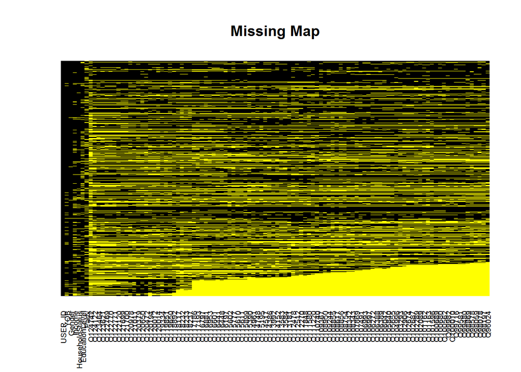

```r
# Missing data by USER_ID ordered from both training and test sets
dfCombined <- rbind(dfRawTrain, dfRawTest) %>% arrange(USER_ID)
Amelia::missmap(dfCombined,
                main="Missing Map", col=c("yellow","black"), legend=F,
                x.cex = 0.6, y.cex = 0.5, y.lab=F, y.at=F, rank.order = F)
```

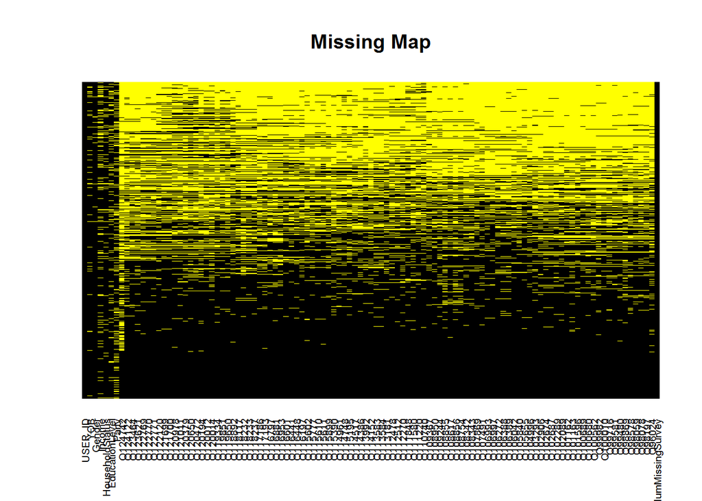

```r
# Missing data by number of missing survey responses
dfCombined$NumMissingSurvey <- apply(dfCombined[vFeaturesSurveyQues], 1, function(Z) sum(is.na(Z)))
dfCombined <- dfCombined %>% arrange(desc(NumMissingSurvey))
Amelia::missmap(dfCombined,
                main="Missing Map", col=c("yellow","black"), legend=F,
                x.cex = 0.6, y.cex = 0.5, y.lab=F, y.at=F, rank.order = F)
```

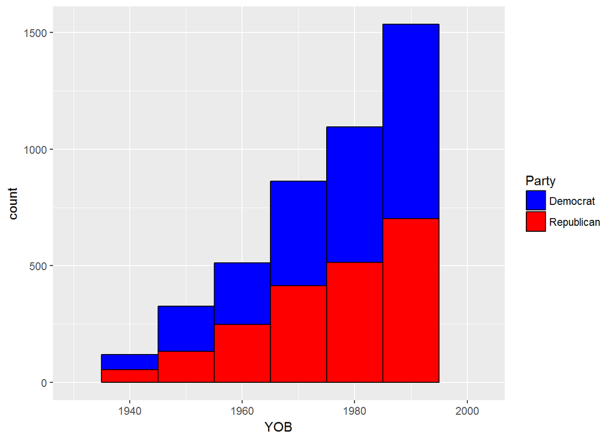

```r
rm(dfCombined)

# Histograms
######################################################################################################
ggplot(dfRawTrain, aes(x = YOB, fill = Party)) +
    geom_histogram(binwidth = 10, color = "black") +
    scale_x_continuous(limits = c(1930, 2003)) +
    scale_fill_manual(values = c("blue","red"))
```

```r
summary(dfRawTrain$YOB)
```

```
##    Min. 1st Qu.  Median    Mean 3rd Qu.    Max.    NA's
##    1880    1970    1983    1980    1993    2039     333
```

```r
# Median YOB by gender: Female 1983, Male 1982
tapply(dfRawTrain$YOB, dfRawTrain$Gender, median, na.rm = T)
```

```
## Female   Male
##   1983   1982
```

```r
# Many outliers and anomalies. For model building exclude YOB > 2003 and YOB < 1930
dfRawTrain[vFeaturesDemographic] %>% subset(YOB > 2003)
```

```
##           Party  YOB Gender        Income  HouseholdStatus  EducationLevel
## 1592 Republican 2039   Male          <NA> Single (no kids)            <NA>
## 3064   Democrat 2011 Female          <NA> Married (w/kids)            <NA>
## 3297   Democrat 2039 Female          <NA> Single (no kids)            <NA>
## 3728 Republican 2013   Male over $150,000 Married (w/kids) Doctoral Degree
```

```r
dfRawTrain[vFeaturesDemographic] %>% subset(YOB < 1930)
```

```
##           Party  YOB Gender              Income             HouseholdStatus      EducationLevel
## 1874   Democrat 1900   Male       over $150,000           Married (no kids)  Associate's Degree
## 2543   Democrat 1928   Male       over $150,000           Married (no kids)   Bachelor's Degree
## 2862 Republican 1900   Male   $50,000 - $74,999            Married (w/kids)                <NA>
## 4125   Democrat 1901   Male   $50,000 - $74,999            Single (no kids)     Master's Degree
## 4660   Democrat 1900   Male  $75,000 - $100,000                        <NA>     Doctoral Degree
## 4830 Republican 1880   Male  $75,000 - $100,000           Married (no kids) High School Diploma
## 4864 Republican 1881 Female $100,001 - $150,000            Married (w/kids)     Master's Degree
## 5054   Democrat 1896 Female   $25,001 - $50,000 Domestic Partners (no kids)        Current K-12
## 5083 Republican 1900   <NA>       over $150,000            Single (no kids)     Doctoral Degree
```

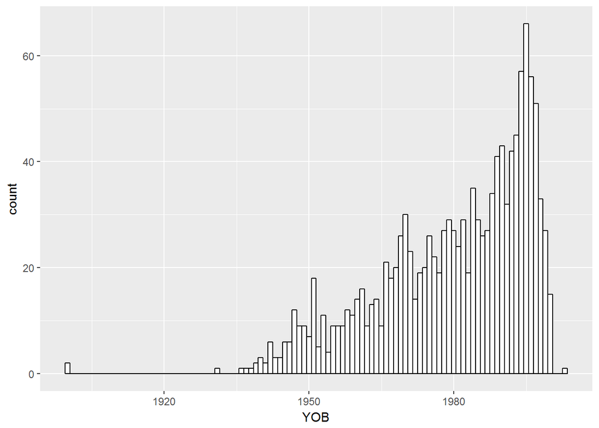

```r
ggplot(dfRawTest, aes(x = YOB)) +
    geom_histogram(binwidth = 1, color = "black", fill = "white")
```

```r
summary(dfRawTest$YOB)
```

```
##    Min. 1st Qu.  Median    Mean 3rd Qu.    Max.    NA's
##    1900    1970    1984    1980    1993    2003      82
```

```r
subset(dfRawTest[vFeaturesDemographic], YOB < 1930)
```

```
##     Party  YOB Gender        Income   HouseholdStatus    EducationLevel
## 257    NA 1900   Male over $150,000  Single (no kids) Bachelor's Degree
## 408    NA 1900 Female over $150,000 Married (no kids) Bachelor's Degree
```

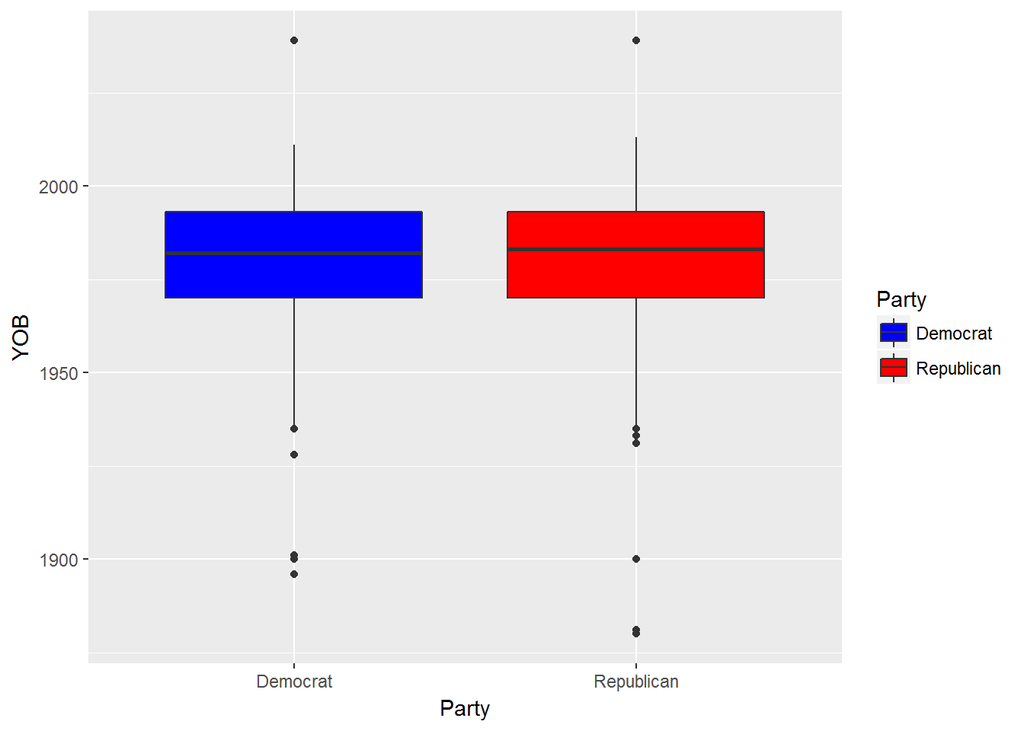

```r
# Boxplots
######################################################################################################
ggplot(dfRawTrain, aes(x = Party, y = YOB, fill = Party)) +
    geom_boxplot(position = "dodge") +
    scale_fill_manual(values = c("blue", "red"))
```

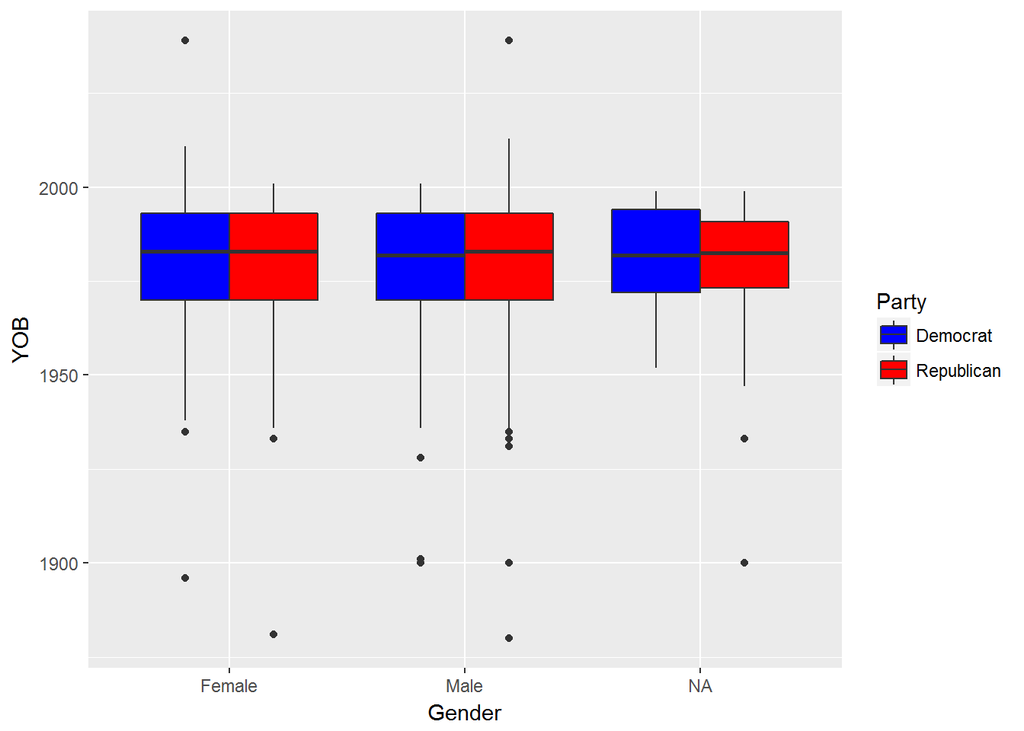

```r
# Nothing remarkable here

ggplot(dfRawTrain, aes(x = Gender, y = YOB, fill = Party)) +
    geom_boxplot(position = "dodge") +
    scale_fill_manual(values = c("blue", "red"))
```